# Cluster Report: All (5 datasets), 40 clusters

Universidad de Deusto (carlos.quesada@deusto.es)

2022-03-03 15:17:43

#### List of abbreviations

##### Sets of features

- **sAggrDRM**: seasonal aggregates v2.0 (day-referenced mean)
- **sAggrP6**: seasonal aggregates v3.0 (6-period time division)

##### Datasets

- **goi**: GoiEner (including Megara and La Corriente) [ES]
- **lcl**: Low Carbon London [GB]
- **iss**: Irish Social Science Data Archive (ISSDA) [IE]
- **por**: Elergone Energia [PT]
- **nee**: Northwest Energy Efficiency Alliance (NEEA) [US]
- **Nds**: N datasets put together

##### Clustering methods

- **som**: self-organizing maps

##### Statistic used

- **μ**: mean
- **σ**: standard deviation

## sAggrDRM > 5ds > som

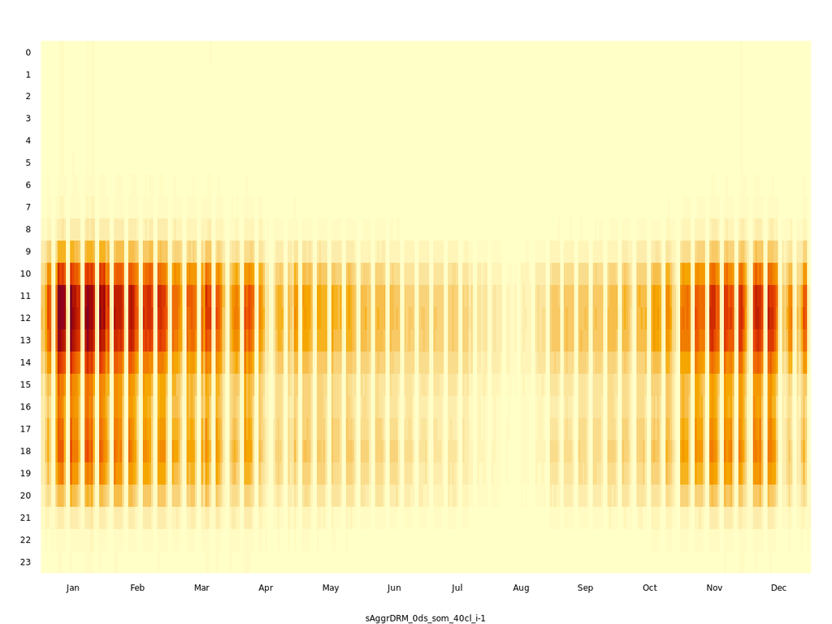

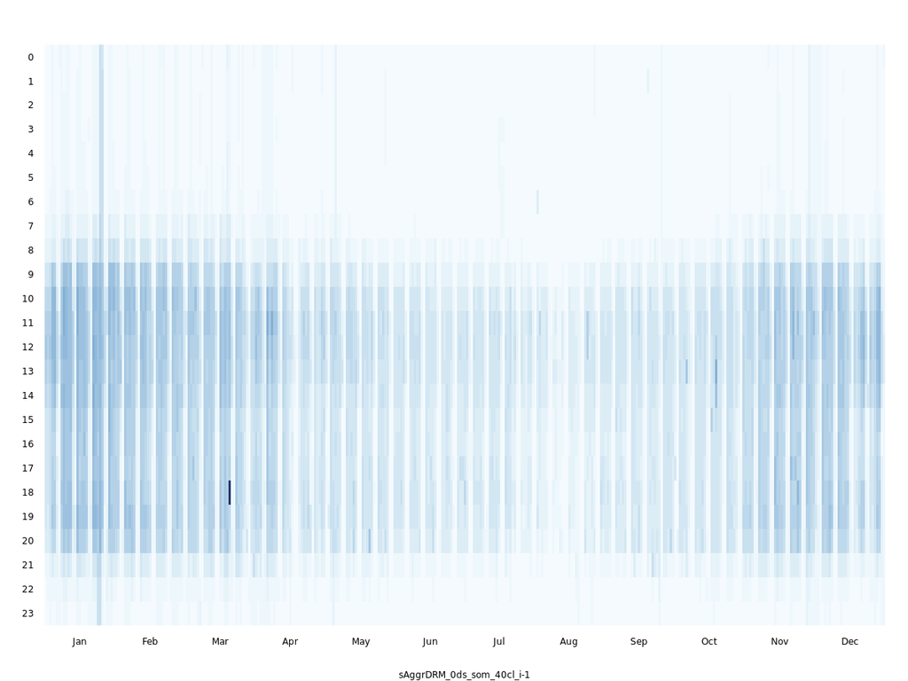

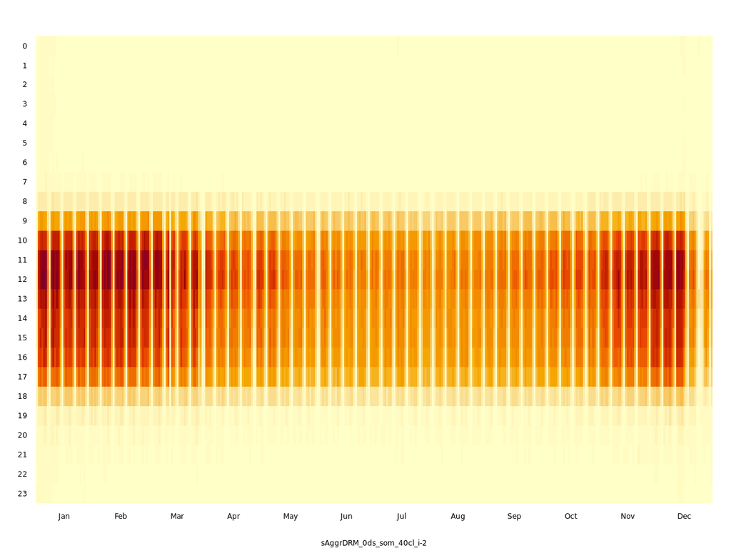

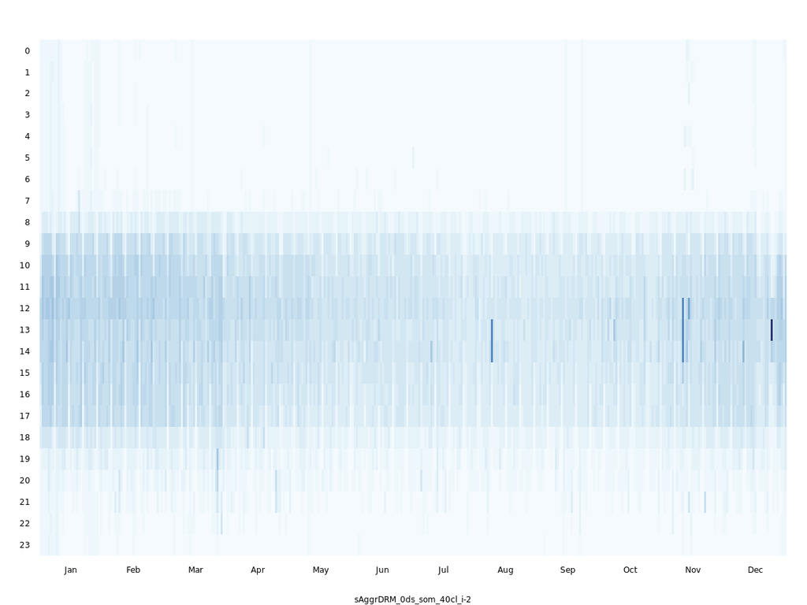

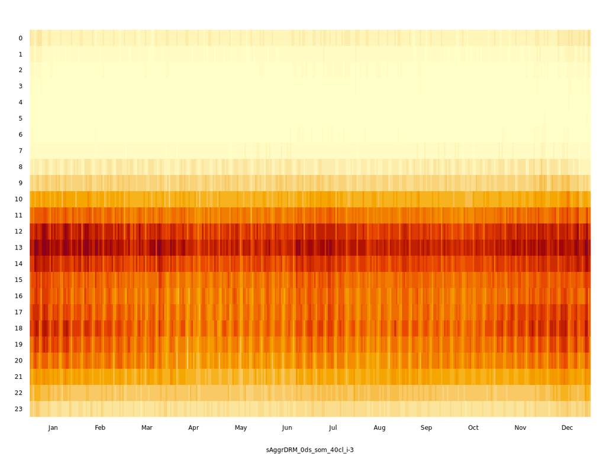

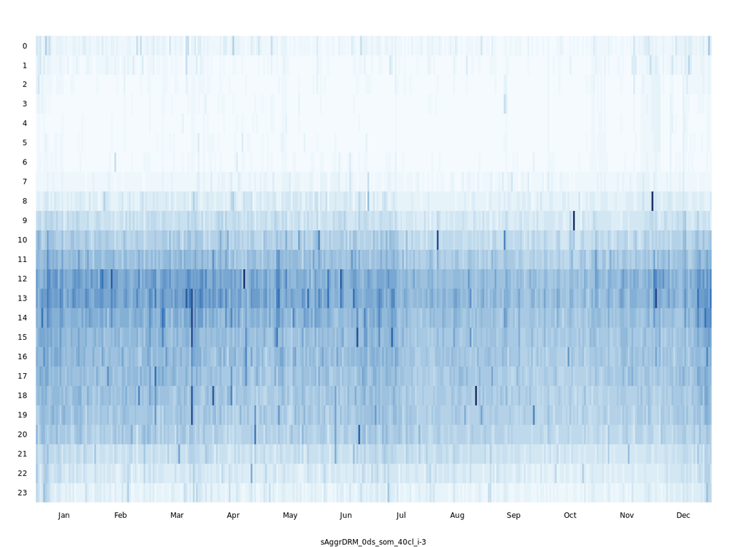

sAggrDRM > 5ds > som > μ > #1

274 TS (1.1%)

sAggrDRM > 5ds > som > σ > #1

274 TS (1.1%)

sAggrDRM > 5ds > som > μ > #2

180 TS (0.8%)

sAggrDRM > 5ds > som > σ > #2

180 TS (0.8%)

sAggrDRM > 5ds > som > μ > #3

272 TS (1.1%)

sAggrDRM > 5ds > som > σ > #3

272 TS (1.1%)

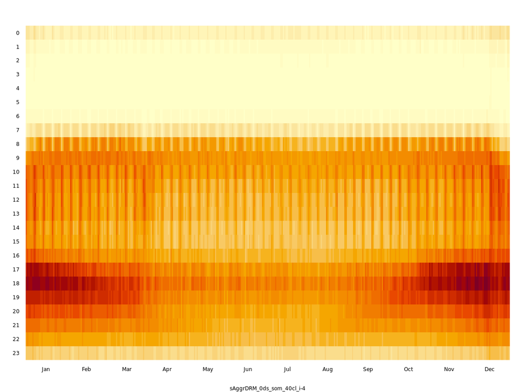

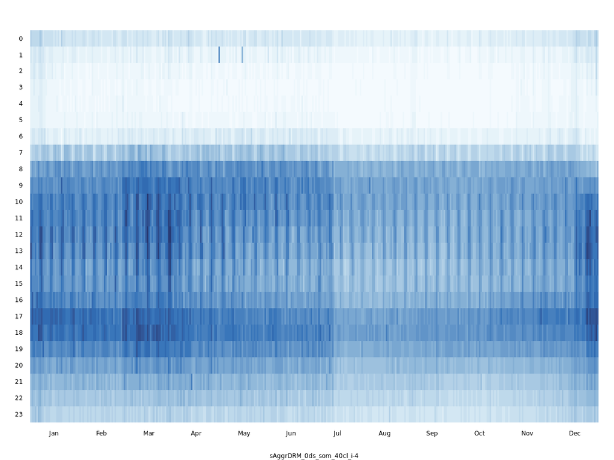

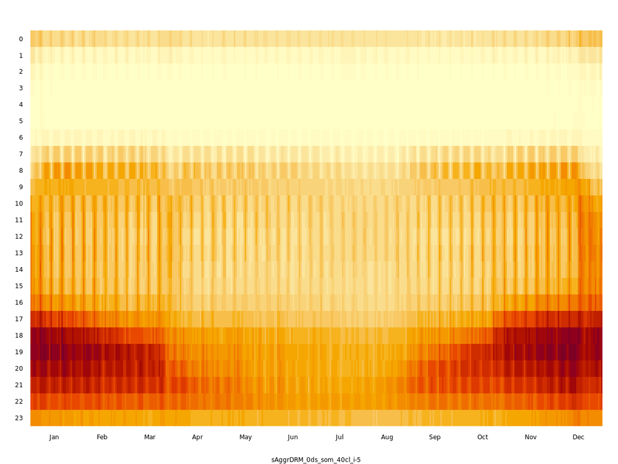

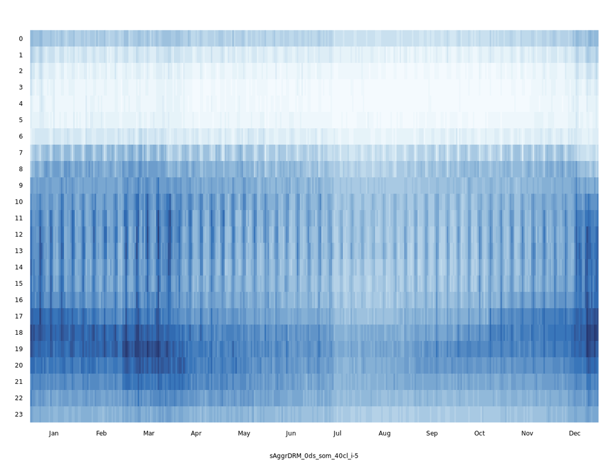

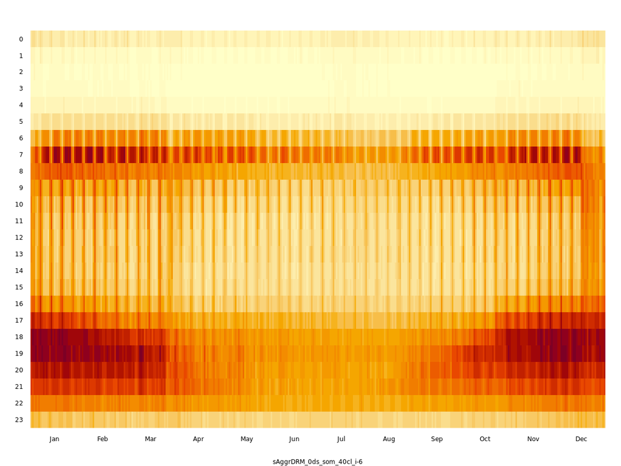

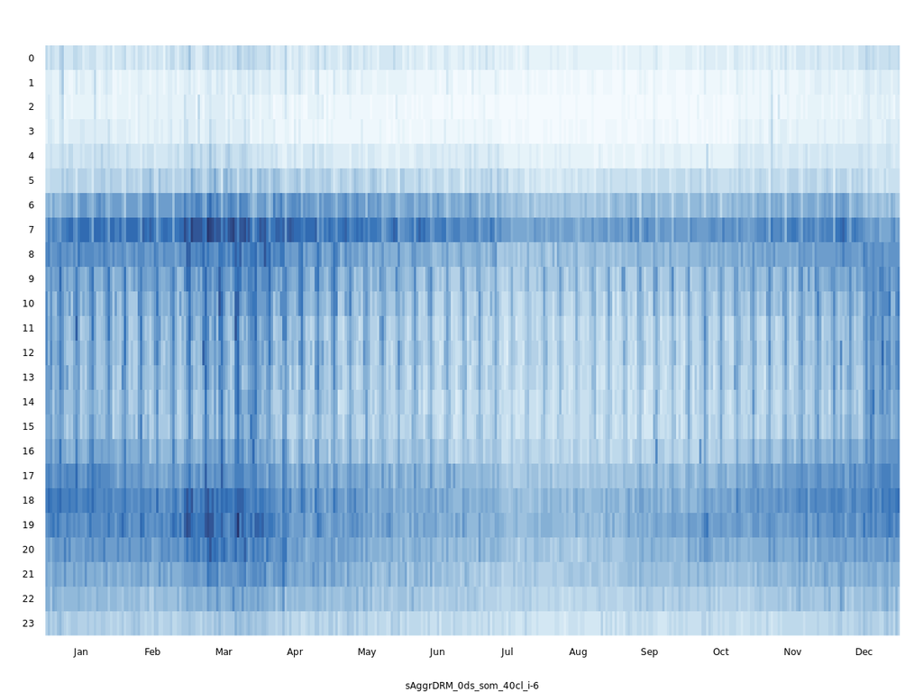

sAggrDRM > 5ds > som > μ > #4

985 TS (4.1%)

sAggrDRM > 5ds > som > σ > #4

985 TS (4.1%)

sAggrDRM > 5ds > som > μ > #5

1849 TS (7.7%)

sAggrDRM > 5ds > som > σ > #5

1849 TS (7.7%)

sAggrDRM > 5ds > som > μ > #6

608 TS (2.5%)

sAggrDRM > 5ds > som > σ > #6

608 TS (2.5%)

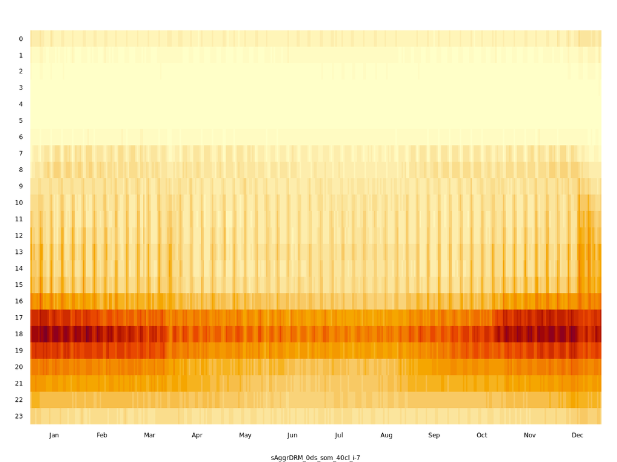

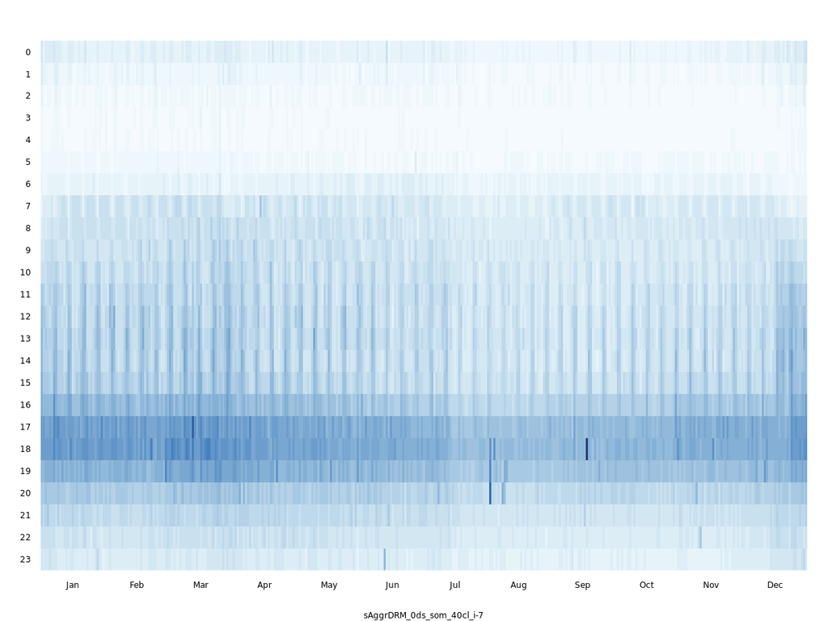

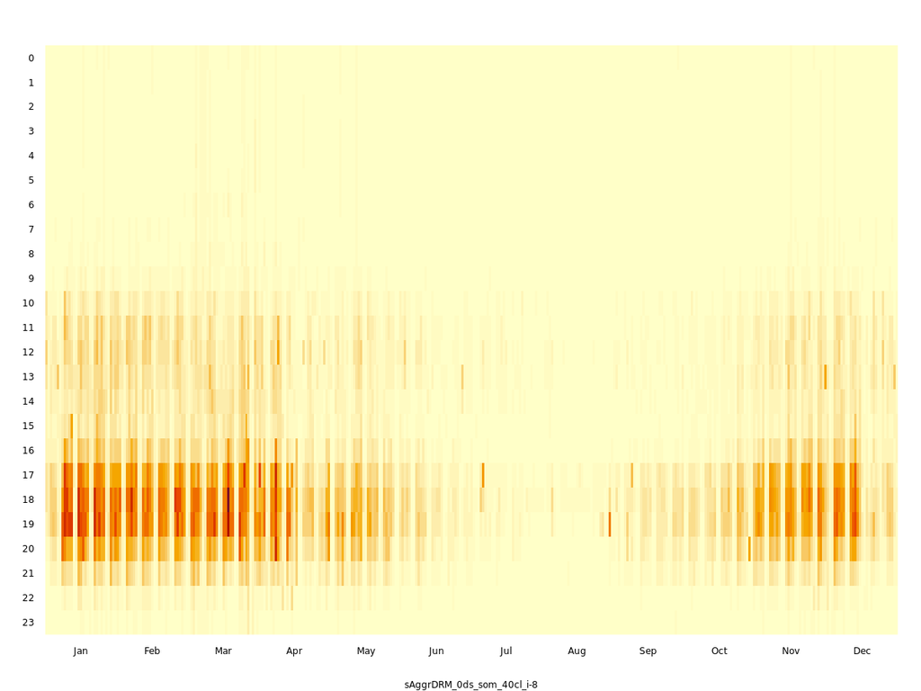

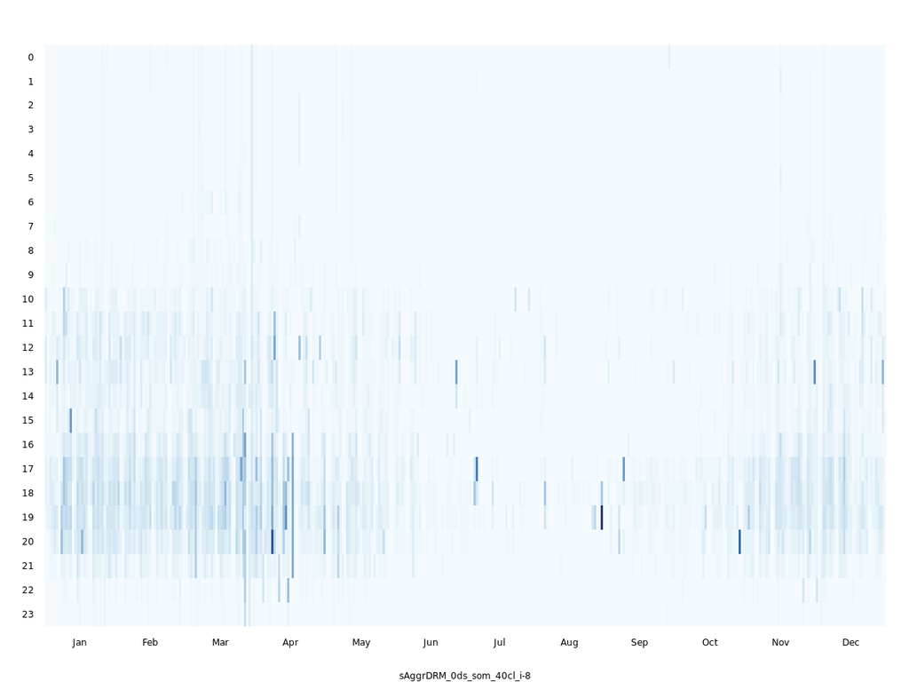

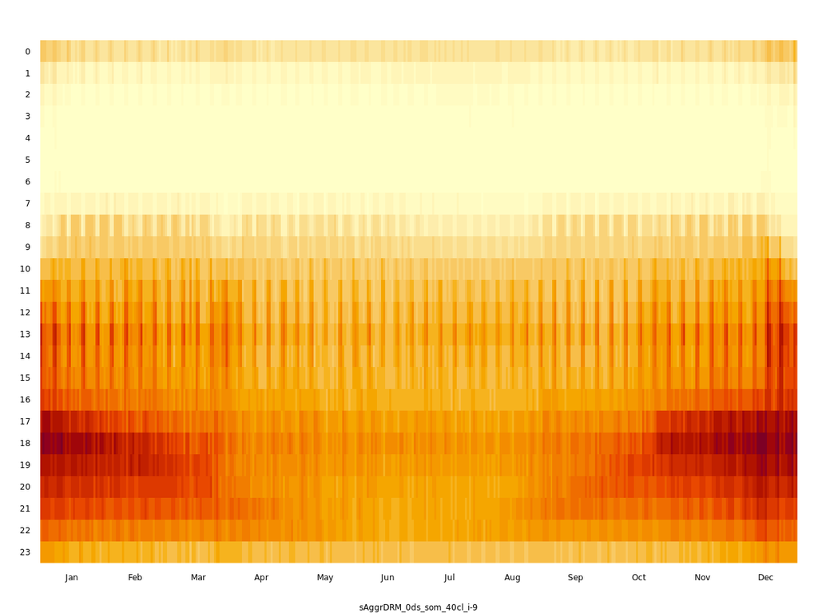

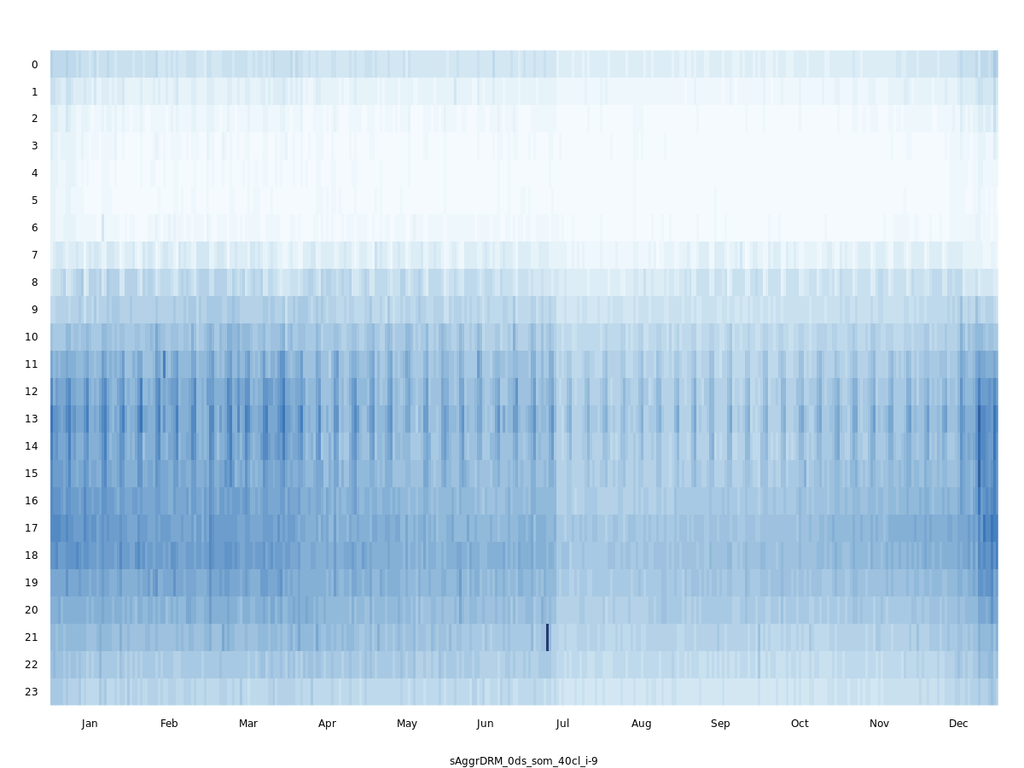

sAggrDRM > 5ds > som > μ > #7

653 TS (2.7%)

sAggrDRM > 5ds > som > σ > #7

653 TS (2.7%)

sAggrDRM > 5ds > som > μ > #8

49 TS (0.2%)

sAggrDRM > 5ds > som > σ > #8

49 TS (0.2%)

sAggrDRM > 5ds > som > μ > #9

1073 TS (4.5%)

sAggrDRM > 5ds > som > σ > #9

1073 TS (4.5%)

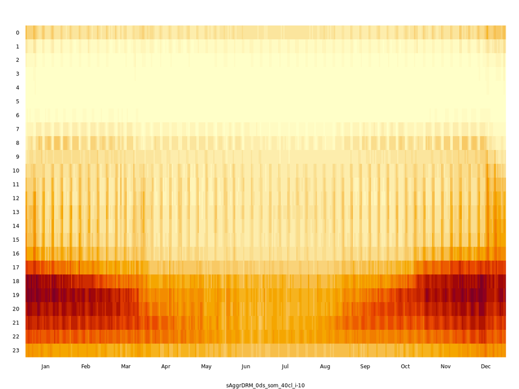

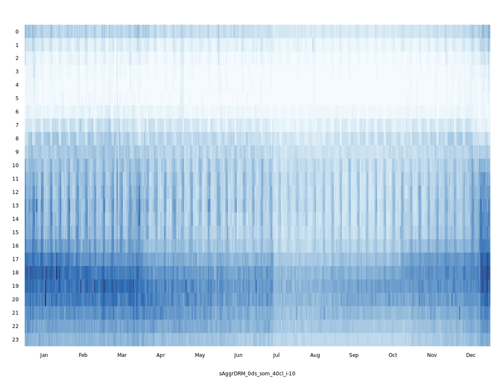

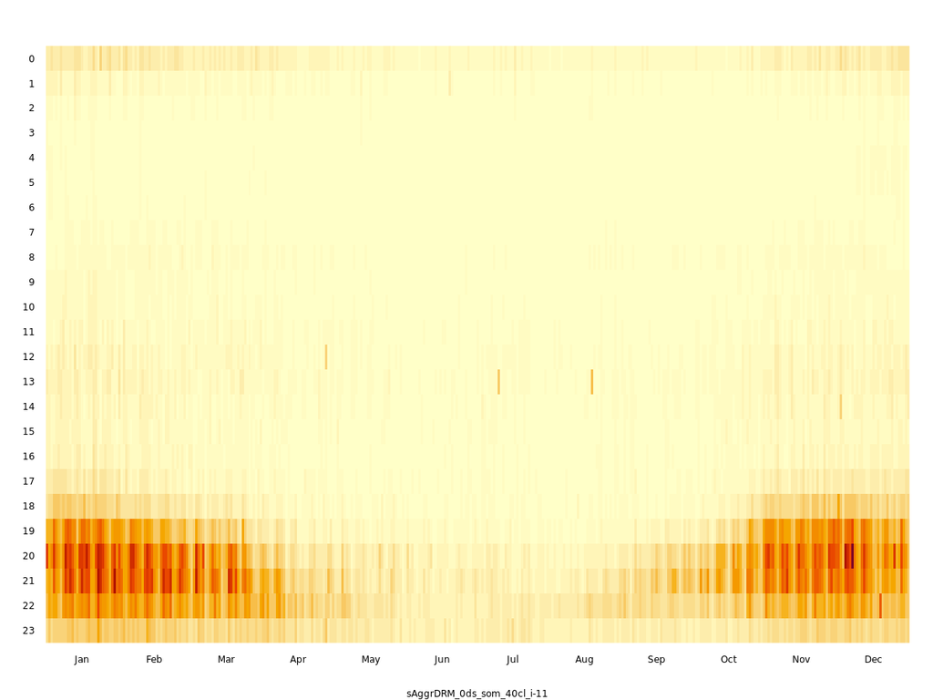

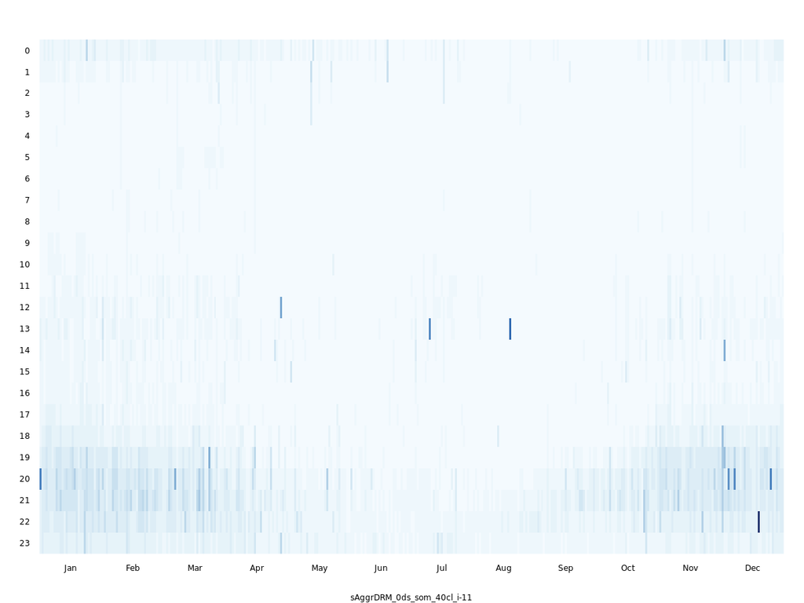

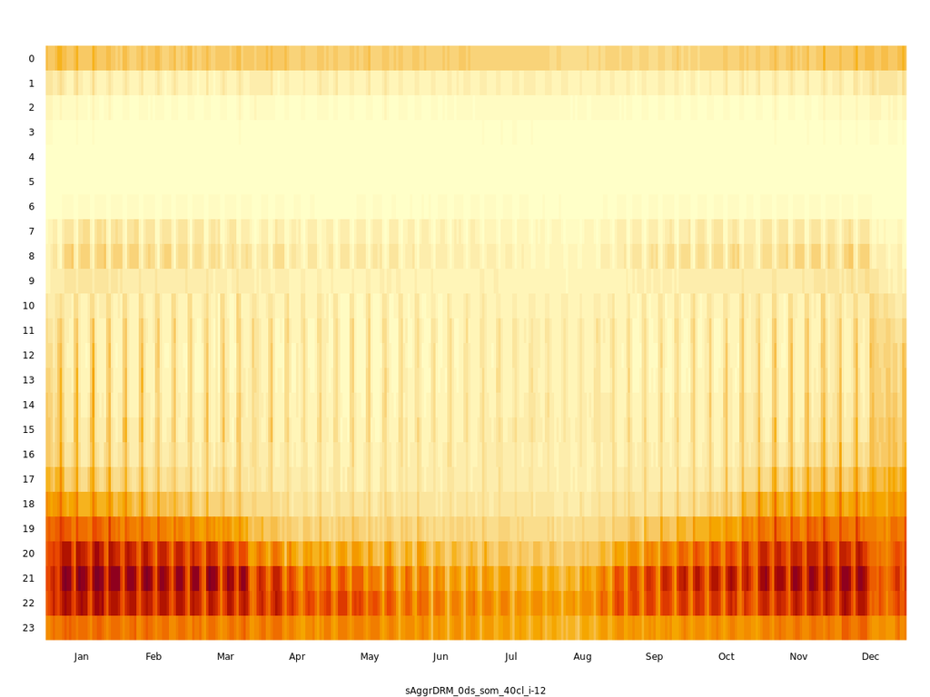

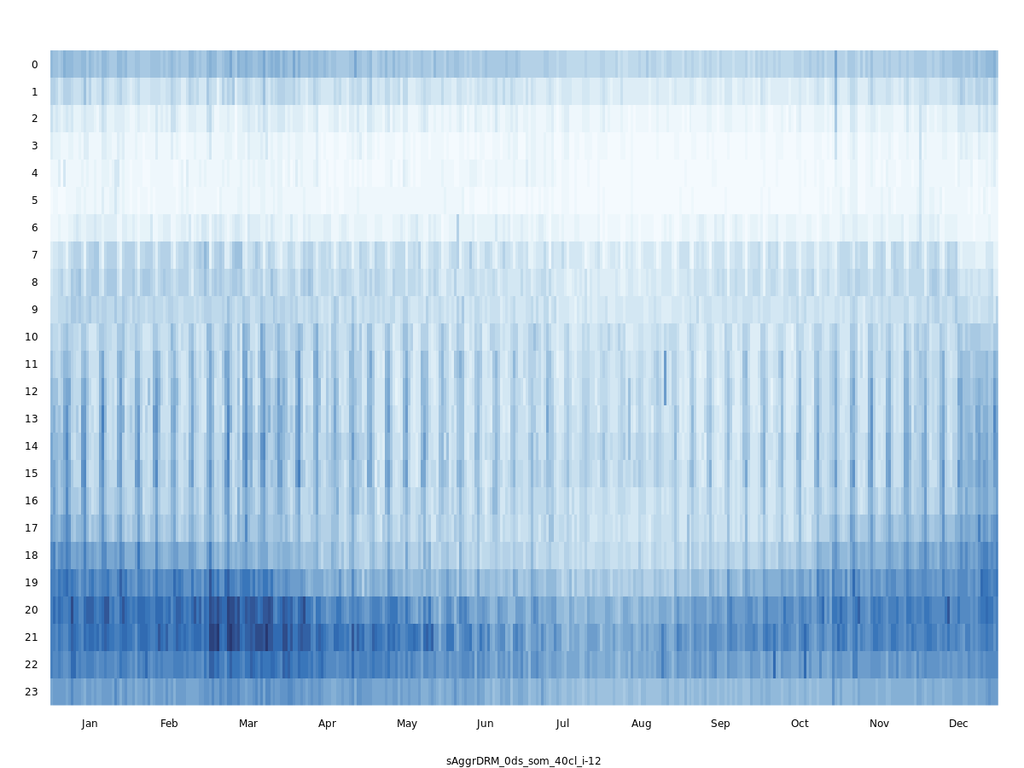

sAggrDRM > 5ds > som > μ > #10

737 TS (3.1%)

sAggrDRM > 5ds > som > σ > #10

737 TS (3.1%)

sAggrDRM > 5ds > som > μ > #11

63 TS (0.3%)

sAggrDRM > 5ds > som > σ > #11

63 TS (0.3%)

sAggrDRM > 5ds > som > μ > #12

712 TS (3%)

sAggrDRM > 5ds > som > σ > #12

712 TS (3%)

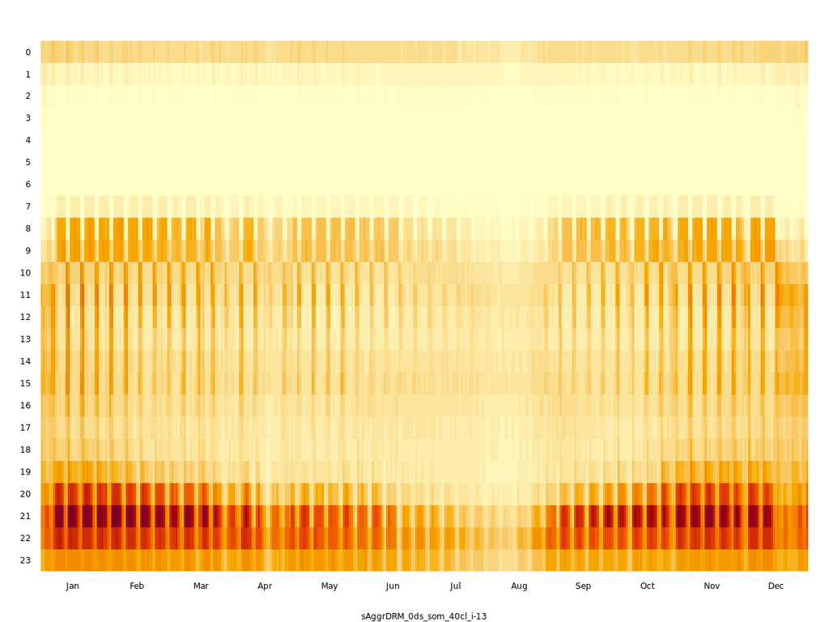

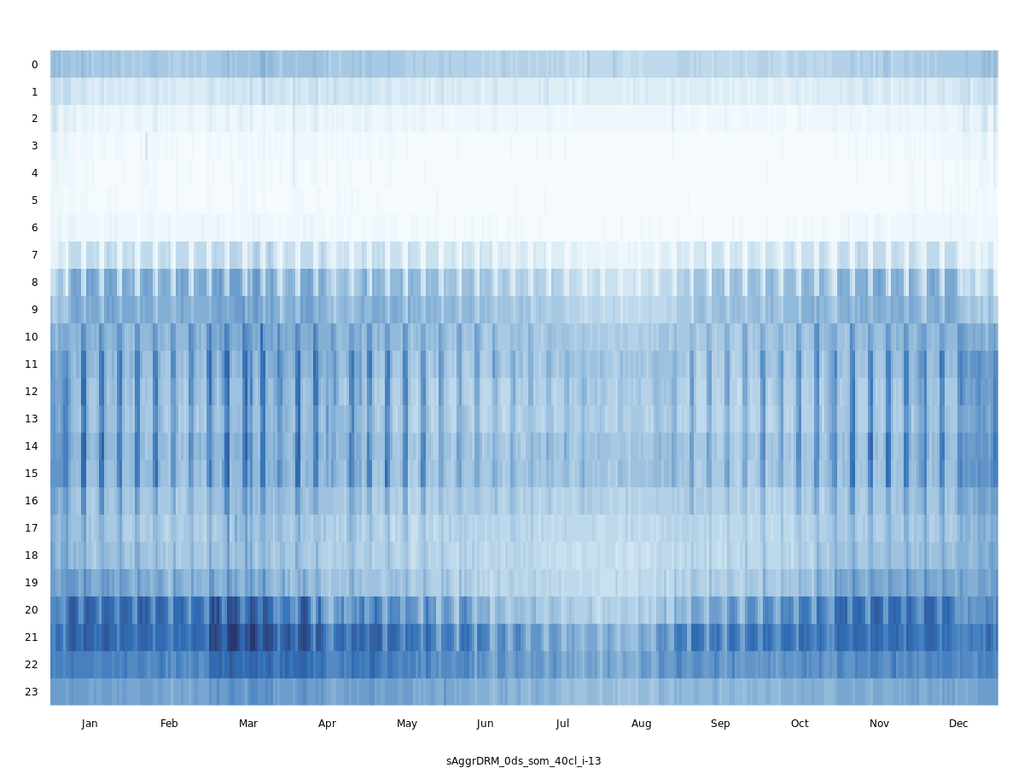

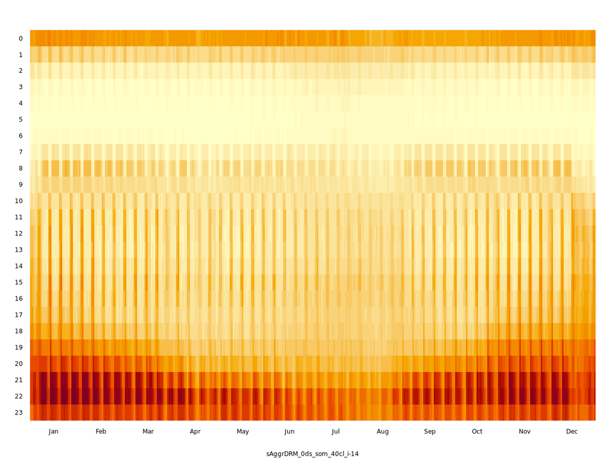

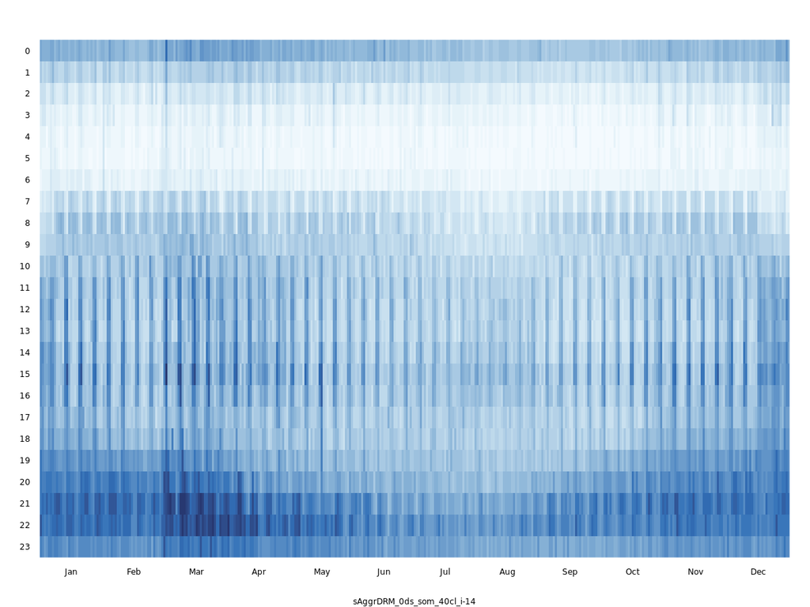

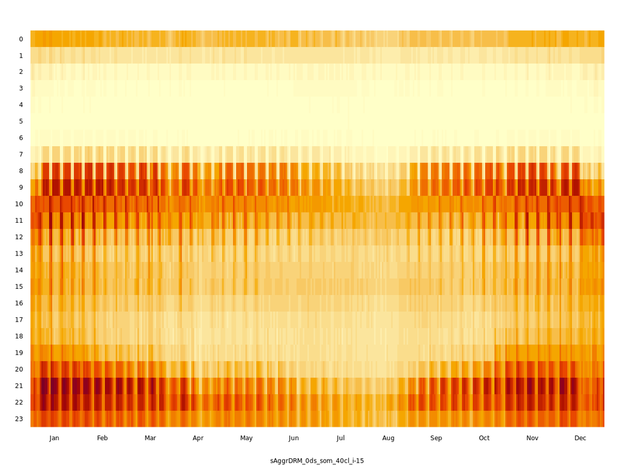

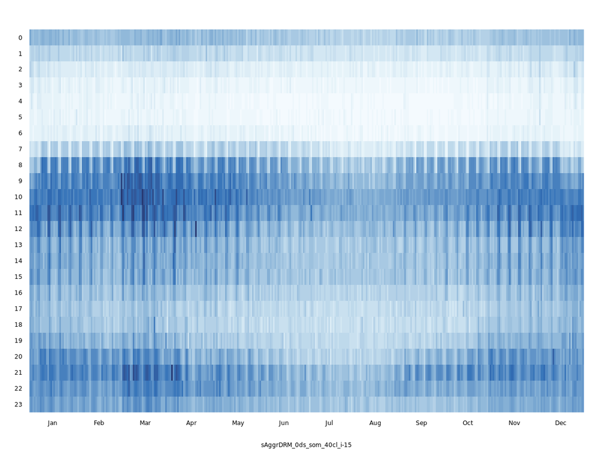

sAggrDRM > 5ds > som > μ > #13

1323 TS (5.5%)

sAggrDRM > 5ds > som > σ > #13

1323 TS (5.5%)

sAggrDRM > 5ds > som > μ > #14

1266 TS (5.3%)

sAggrDRM > 5ds > som > σ > #14

1266 TS (5.3%)

sAggrDRM > 5ds > som > μ > #15

971 TS (4.1%)

sAggrDRM > 5ds > som > σ > #15

971 TS (4.1%)

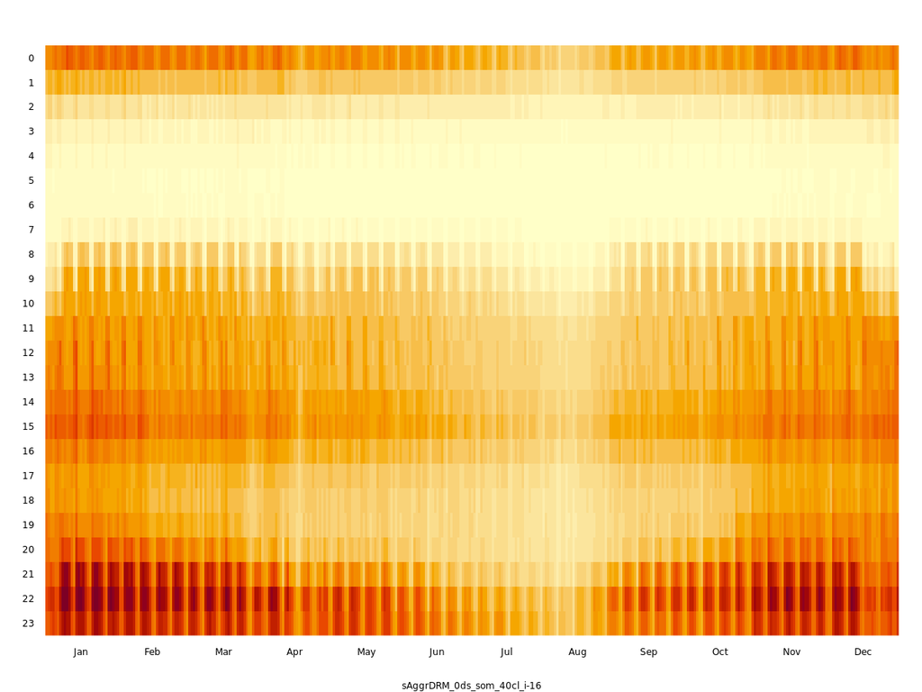

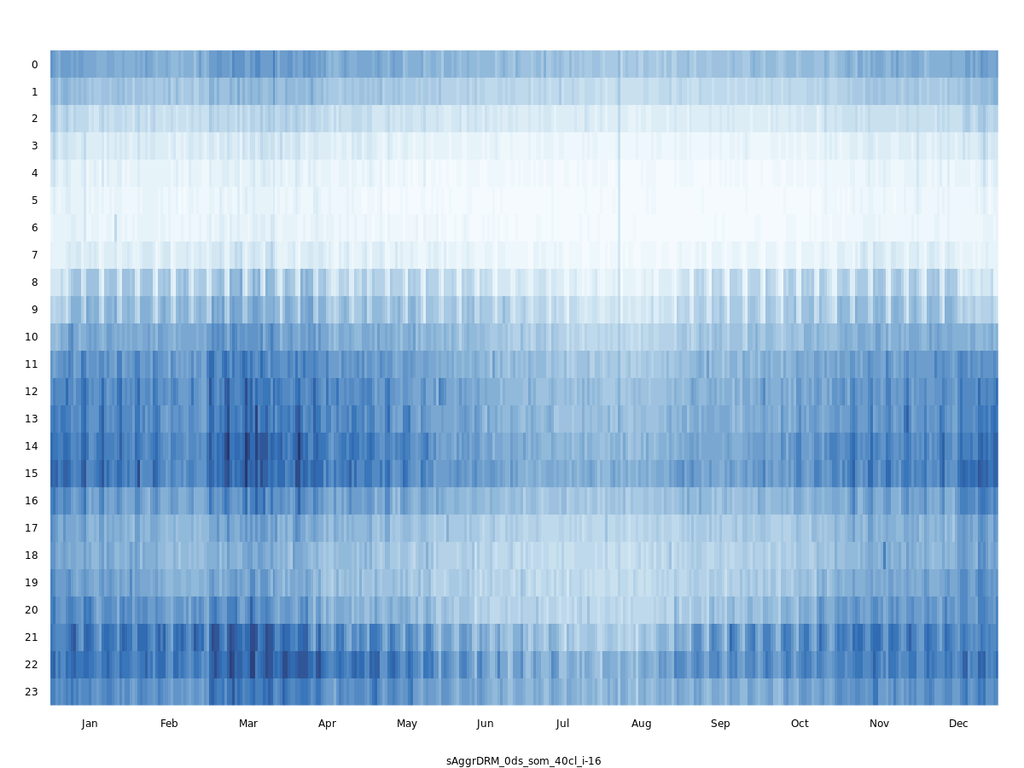

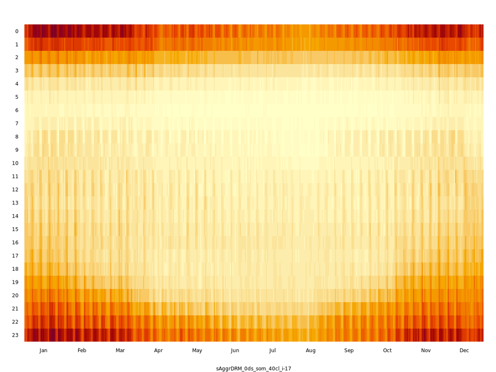

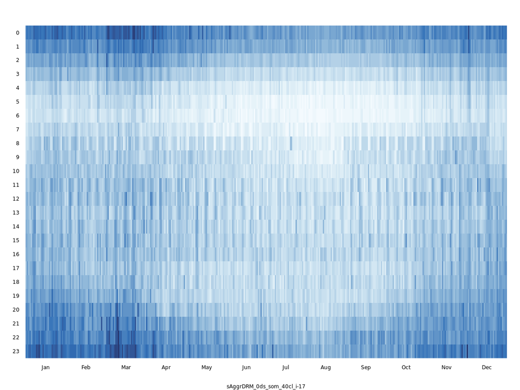

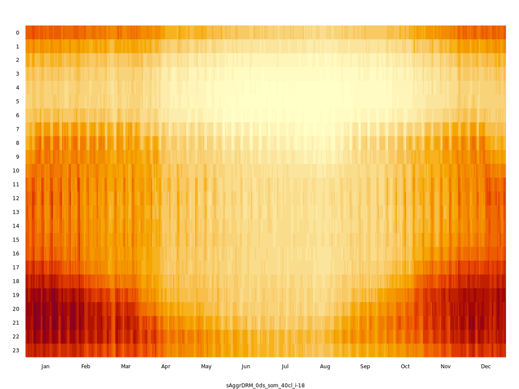

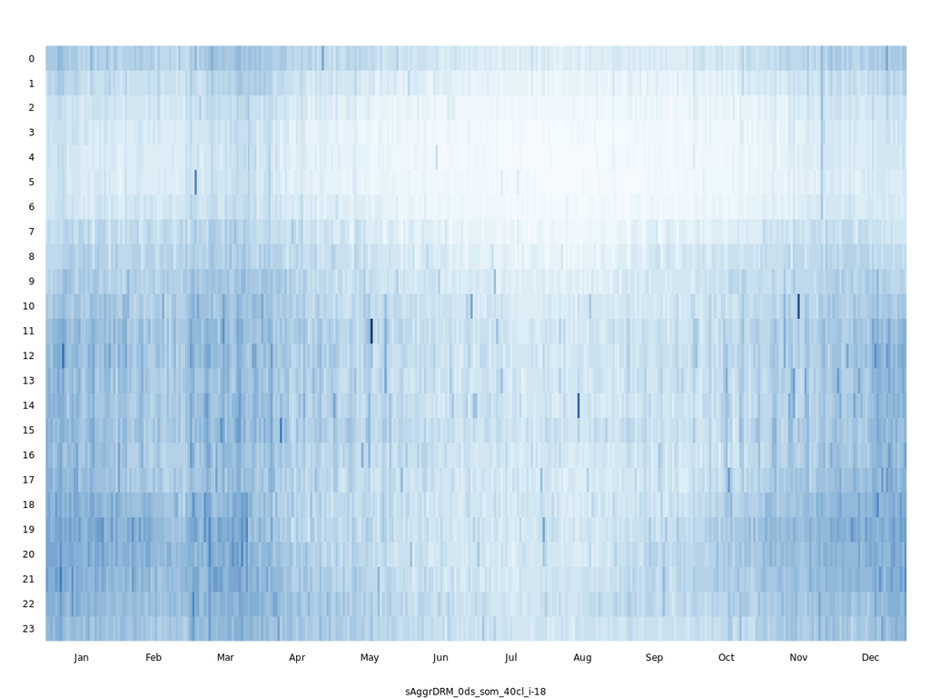

sAggrDRM > 5ds > som > μ > #16

989 TS (4.1%)

sAggrDRM > 5ds > som > σ > #16

989 TS (4.1%)

sAggrDRM > 5ds > som > μ > #17

393 TS (1.6%)

sAggrDRM > 5ds > som > σ > #17

393 TS (1.6%)

sAggrDRM > 5ds > som > μ > #18

1031 TS (4.3%)

sAggrDRM > 5ds > som > σ > #18

1031 TS (4.3%)

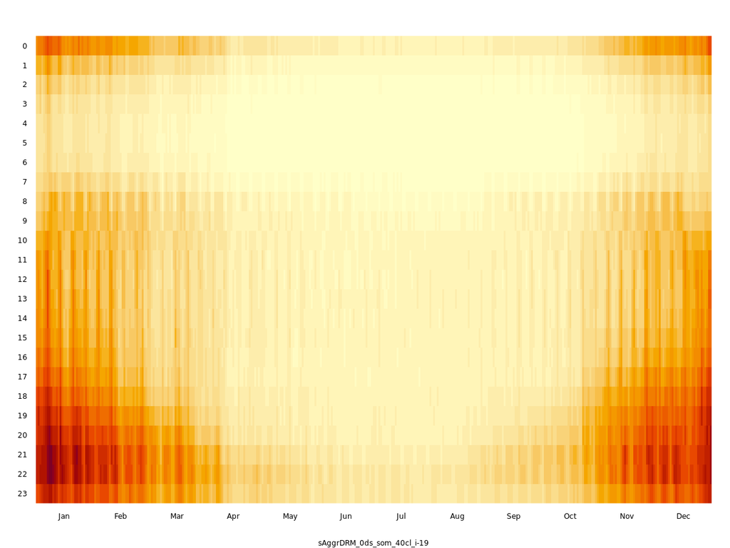

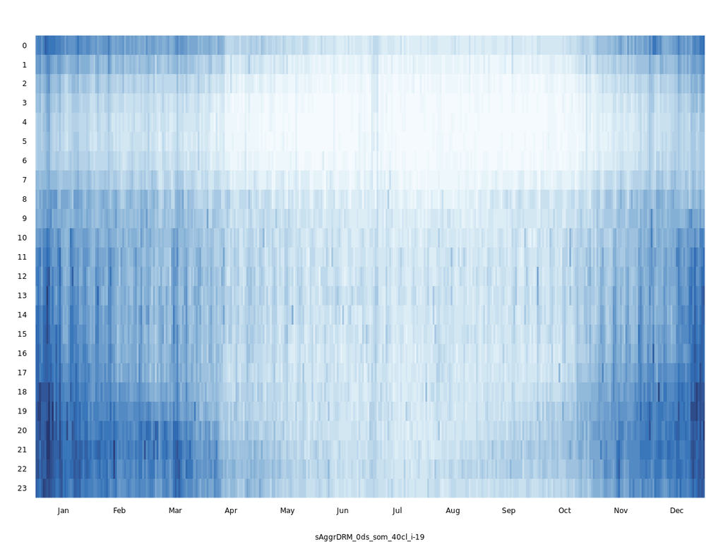

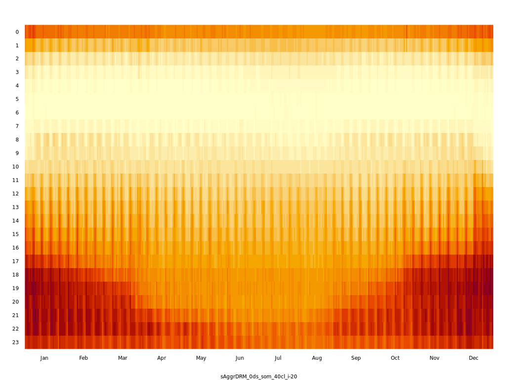

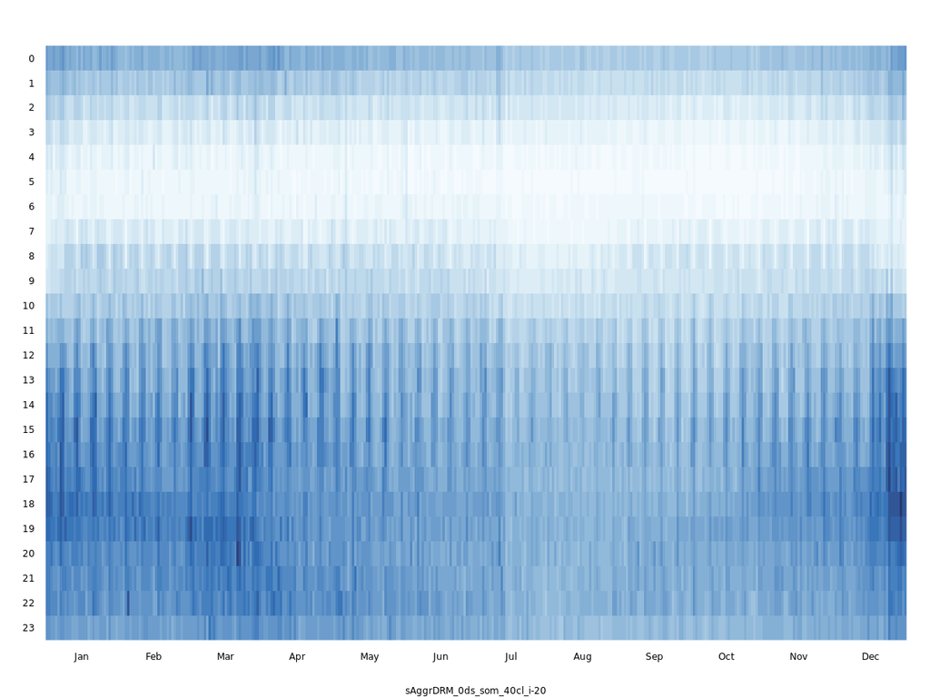

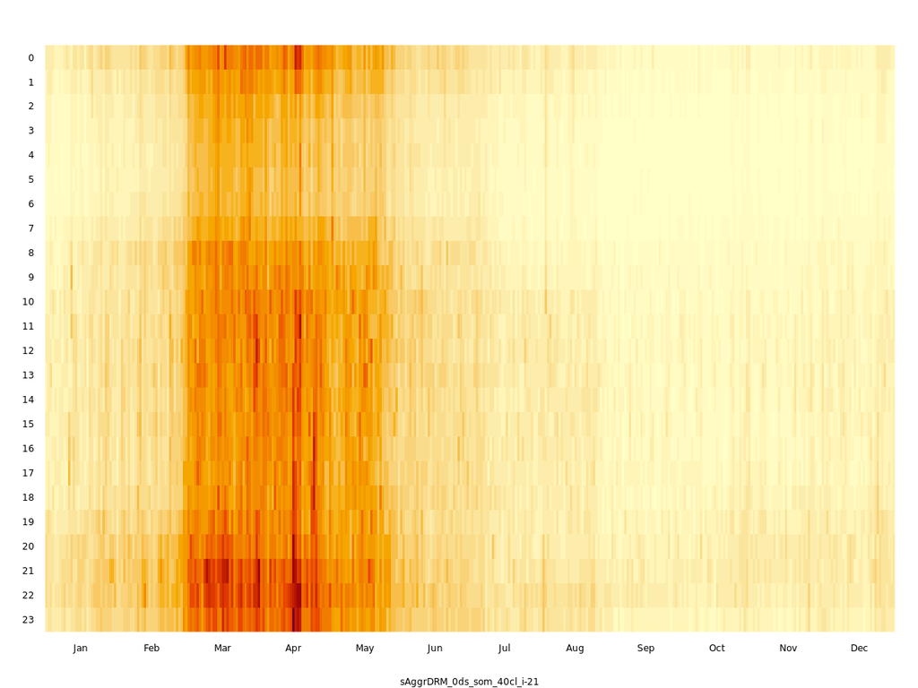

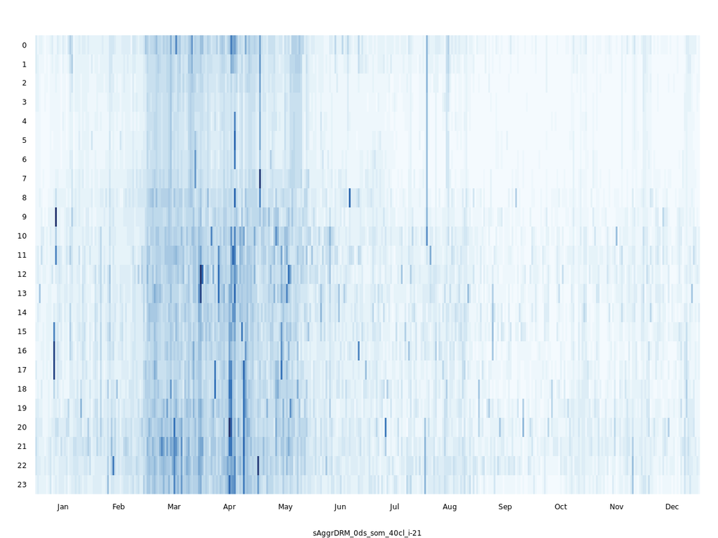

sAggrDRM > 5ds > som > μ > #19

572 TS (2.4%)

sAggrDRM > 5ds > som > σ > #19

572 TS (2.4%)

sAggrDRM > 5ds > som > μ > #20

1139 TS (4.8%)

sAggrDRM > 5ds > som > σ > #20

1139 TS (4.8%)

sAggrDRM > 5ds > som > μ > #21

117 TS (0.5%)

sAggrDRM > 5ds > som > σ > #21

117 TS (0.5%)

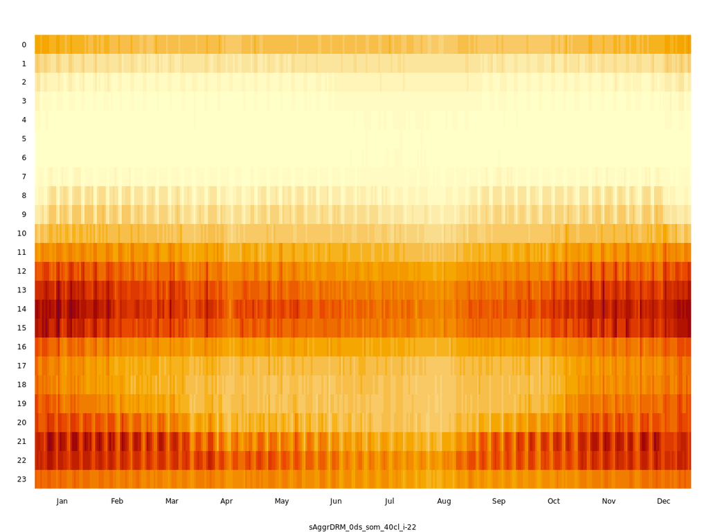

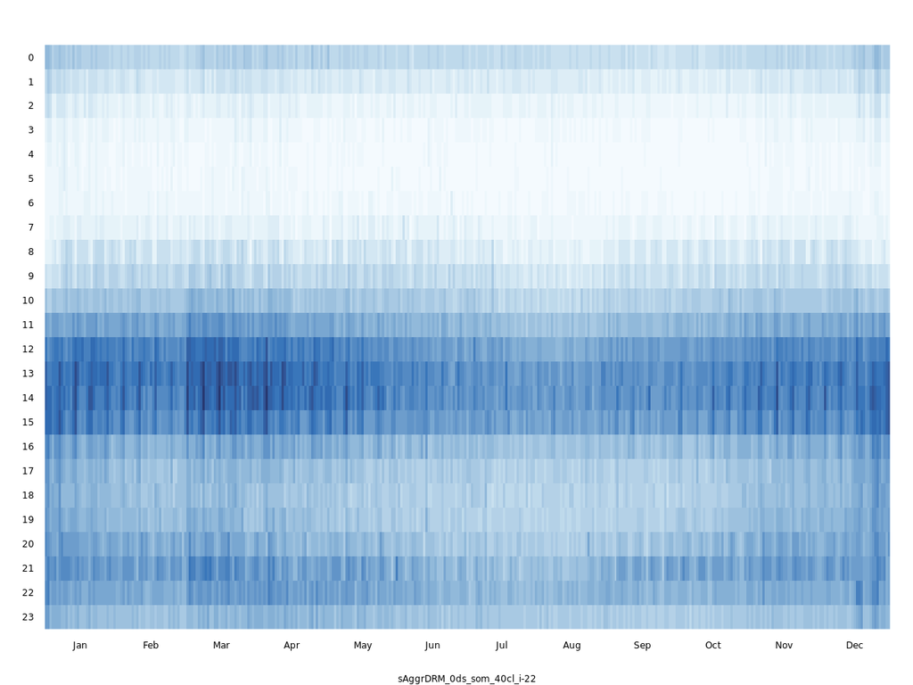

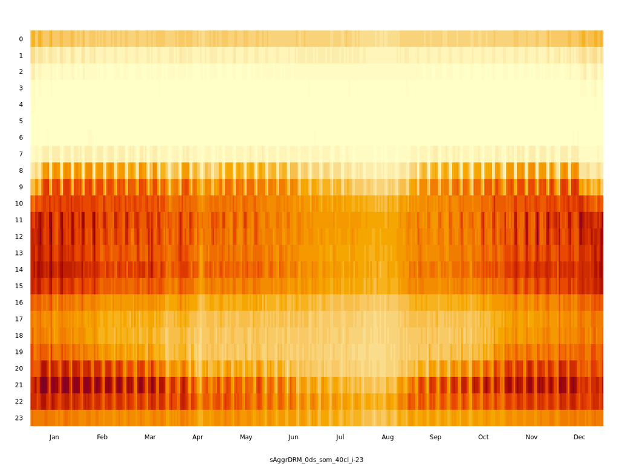

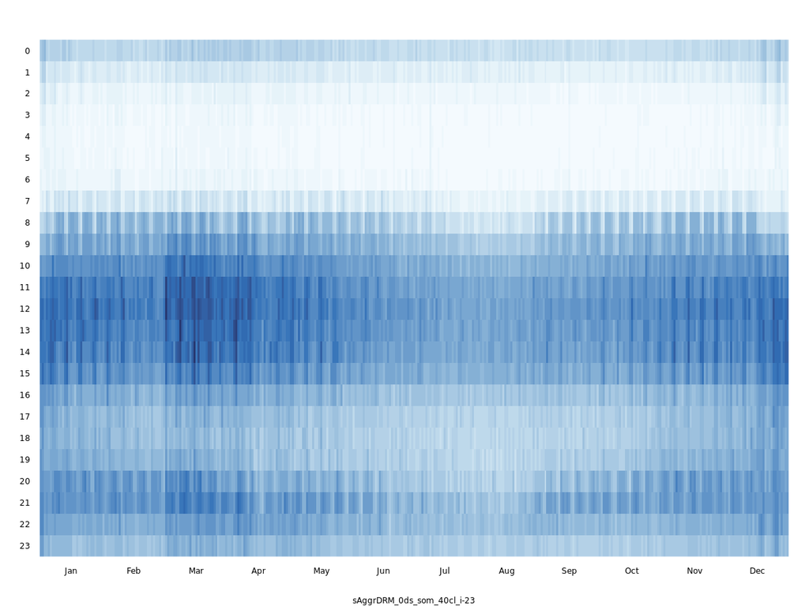

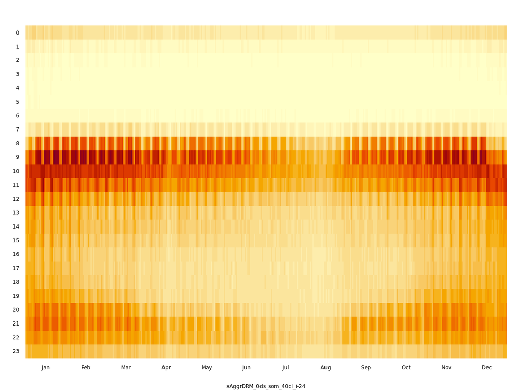

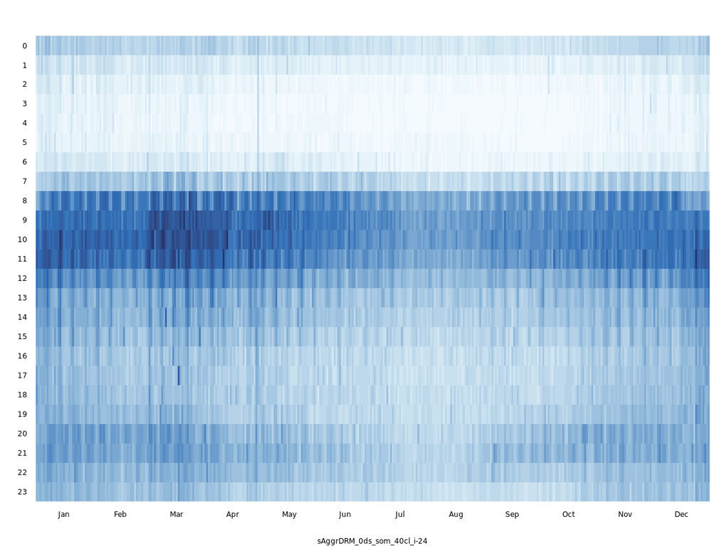

sAggrDRM > 5ds > som > μ > #22

882 TS (3.7%)

sAggrDRM > 5ds > som > σ > #22

882 TS (3.7%)

sAggrDRM > 5ds > som > μ > #23

1050 TS (4.4%)

sAggrDRM > 5ds > som > σ > #23

1050 TS (4.4%)

sAggrDRM > 5ds > som > μ > #24

510 TS (2.1%)

sAggrDRM > 5ds > som > σ > #24

510 TS (2.1%)

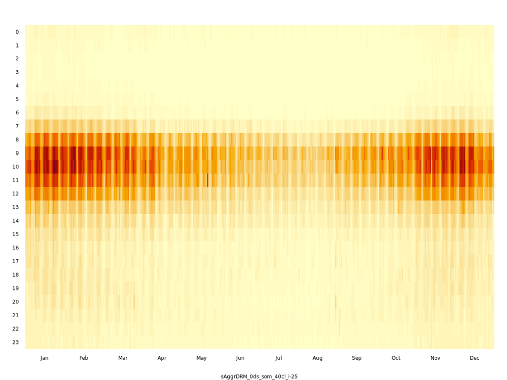

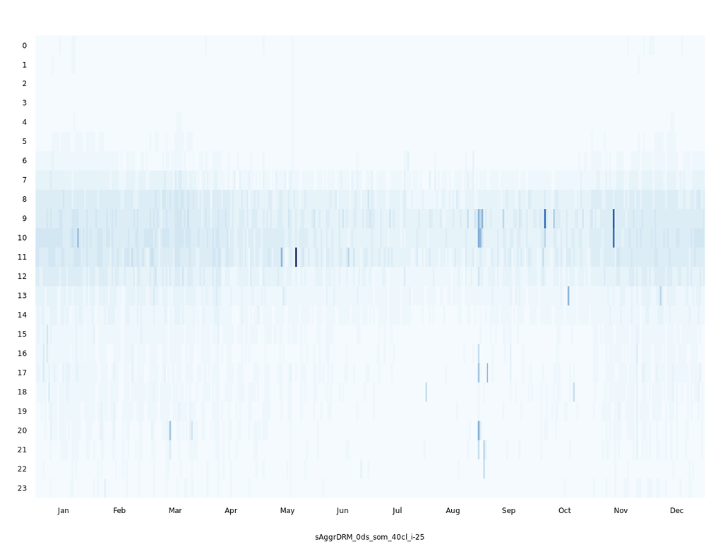

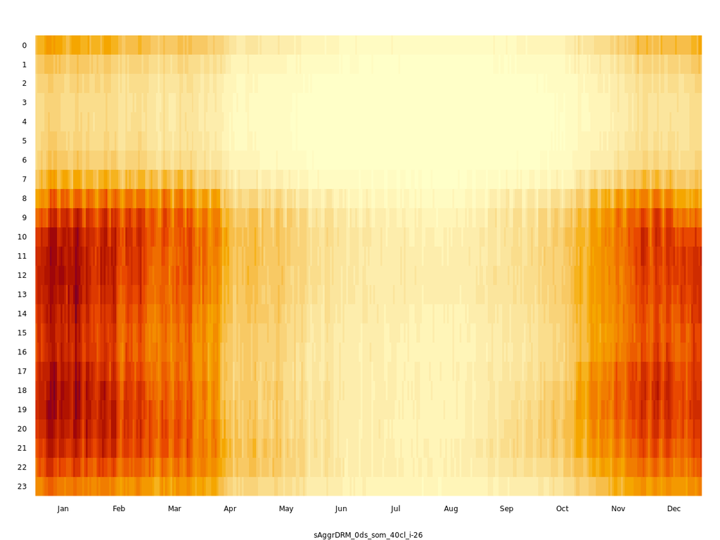

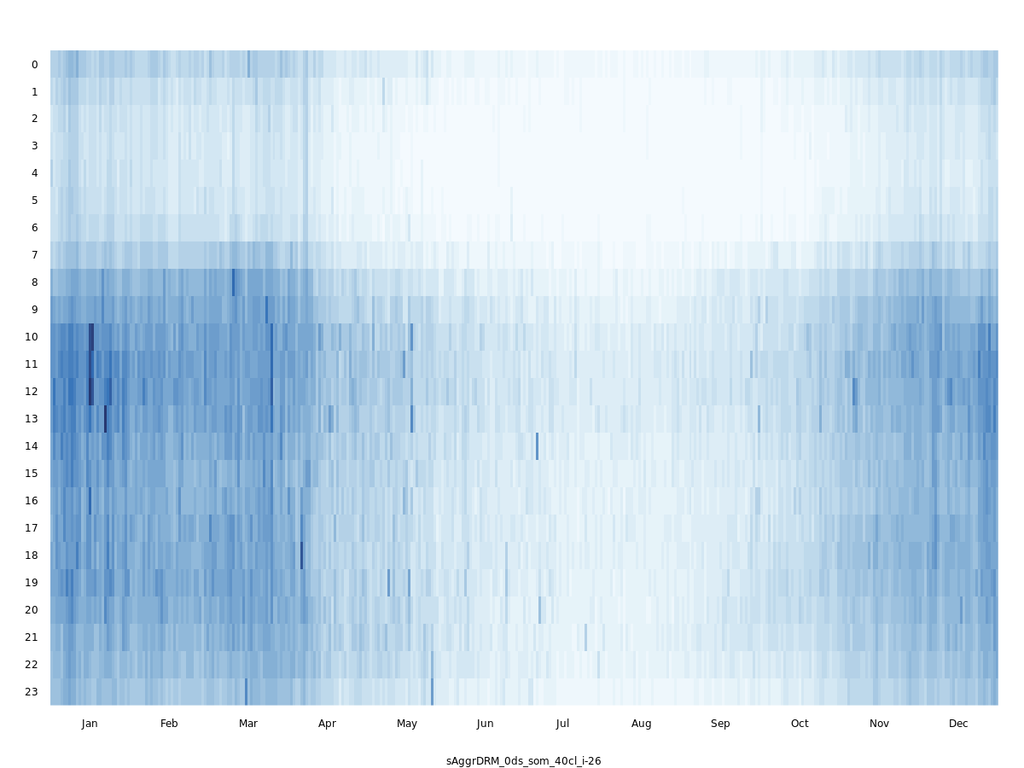

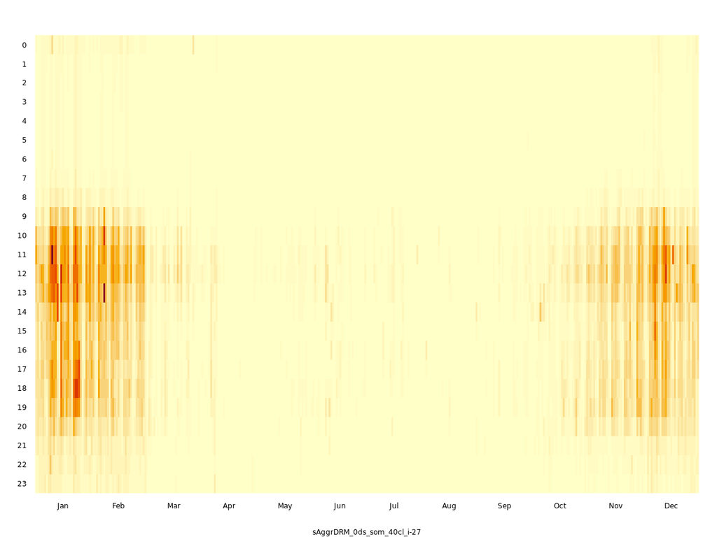

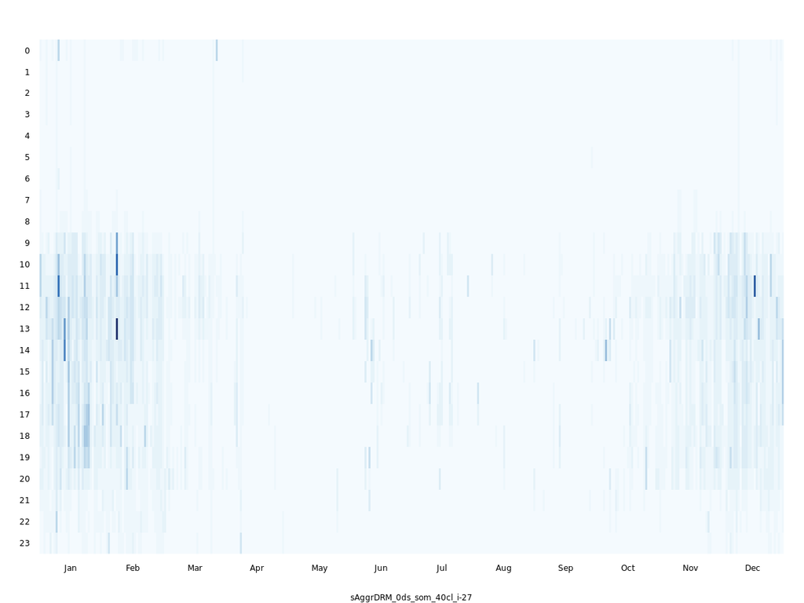

sAggrDRM > 5ds > som > μ > #25

75 TS (0.3%)

sAggrDRM > 5ds > som > σ > #25

75 TS (0.3%)

sAggrDRM > 5ds > som > μ > #26

422 TS (1.8%)

sAggrDRM > 5ds > som > σ > #26

422 TS (1.8%)

sAggrDRM > 5ds > som > μ > #27

40 TS (0.2%)

sAggrDRM > 5ds > som > σ > #27

40 TS (0.2%)

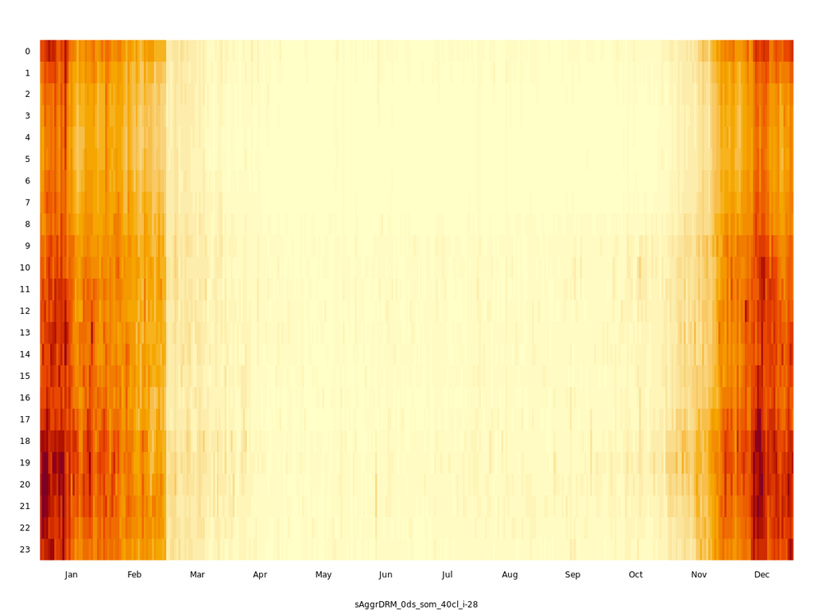

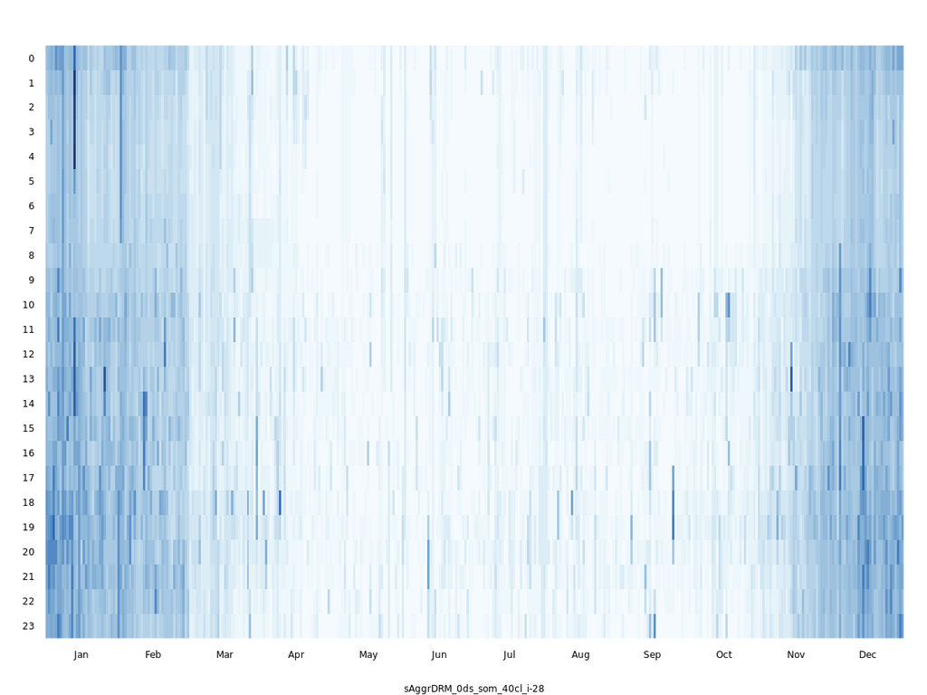

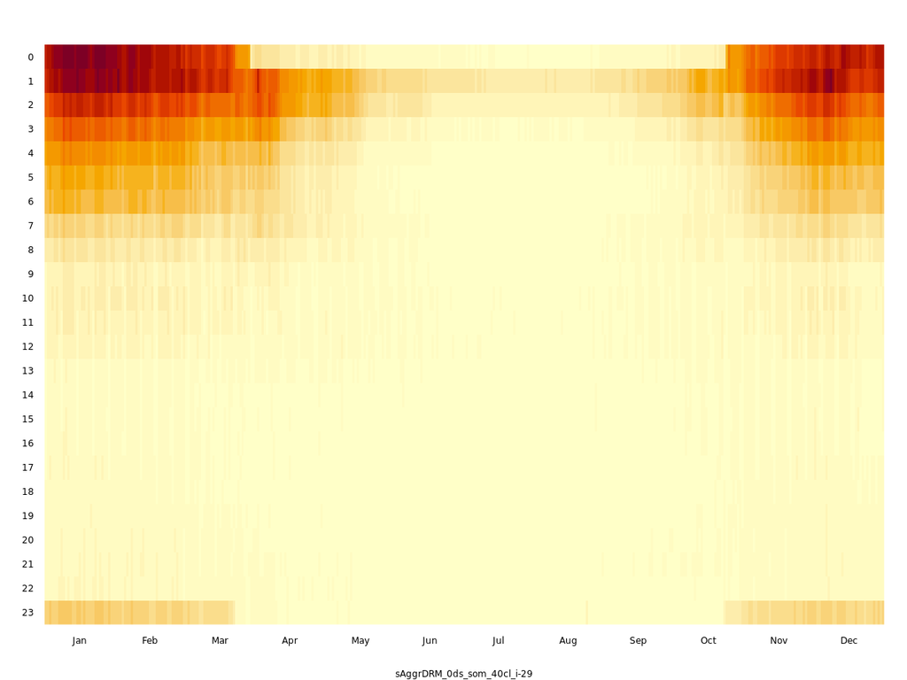

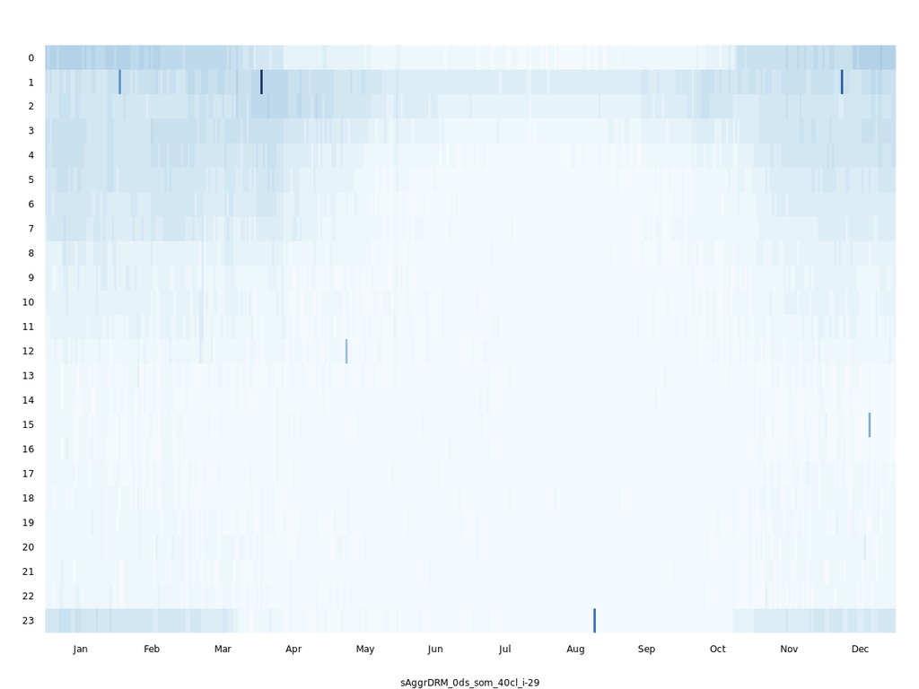

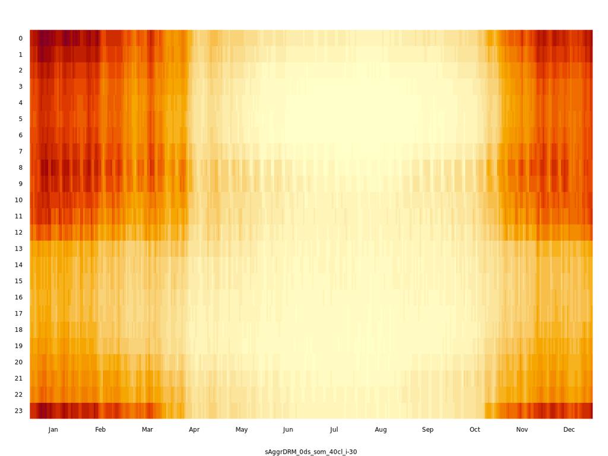

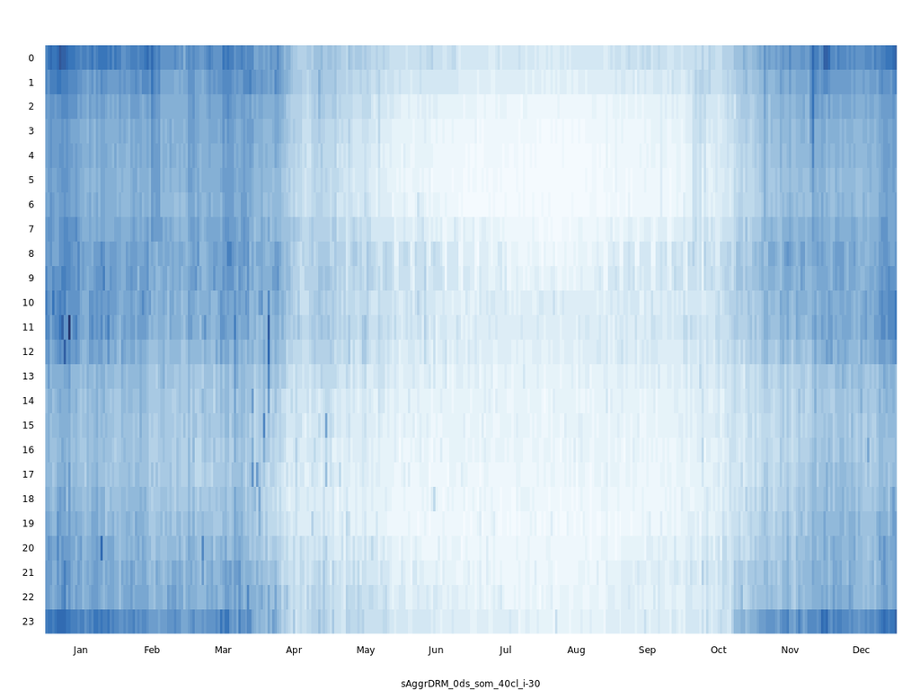

sAggrDRM > 5ds > som > μ > #28

104 TS (0.4%)

sAggrDRM > 5ds > som > σ > #28

104 TS (0.4%)

sAggrDRM > 5ds > som > μ > #29

118 TS (0.5%)

sAggrDRM > 5ds > som > σ > #29

118 TS (0.5%)

sAggrDRM > 5ds > som > μ > #30

405 TS (1.7%)

sAggrDRM > 5ds > som > σ > #30

405 TS (1.7%)

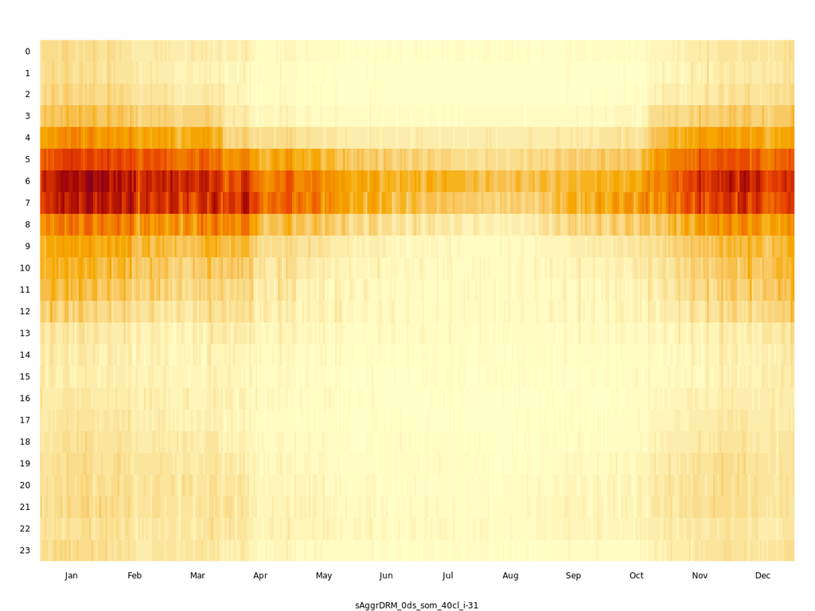

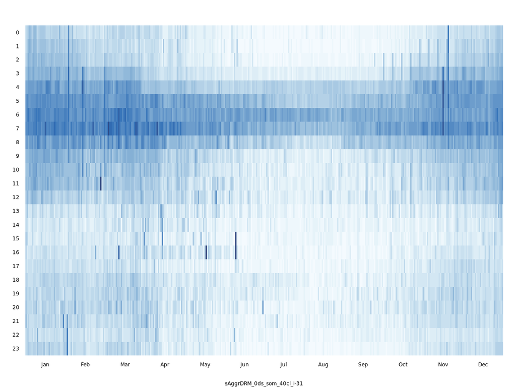

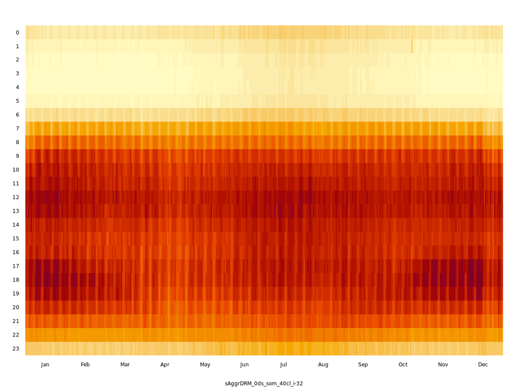